# Dates and Times

Using the `lubridate` package

Material adapted from the textbook, *“R for Data Science”* (R4DS) by Hadley Wickham and Garret Grolemund. The official website of the textbook is http://r4ds.had.co.nz/

Load the required packages

```r
library(tidyverse)
```

## Introduction

- Does every year have 365 days?
- Does every day have 24 hours?
- Does every minute have 60 seconds?

Do you know the full rule for determining if a year is a leap year? (It has three parts.) You might have remembered that many parts of the world use daylight savings time (DST), so that some days have 23 hours, and others have 25. You might not have known that some minutes have 61 seconds because every now and then leap seconds are added because the Earth’s rotation is gradually slowing down.

We will focus on the `lubridate` package, which makes it easier to work with dates and times in R. `lubridate` is not part of core `tidyverse` because you only need it when you’re working with dates/times. We will also need `nycflights13` for practice data.

```r
library(lubridate)
library(nycflights13)
```

## Creating date/times

There are three types of date/time data that refer to an instant in time:

- A **date**. Tibbles print this as `<date>`.
- A **time** within a day. Tibbles print this as `<time>`.
- A **date-time** is a date plus a time: it uniquely identifies an instant in time (typically to the nearest second). Tibbles print this as `<dttm>`. Elsewhere in R these are called `POSIXct`.

To get the current date or date-time you can use `today()` or `now()`:

```r
# use today and now
today()
```

```
[1] "2020-01-29"
```

```r
now()
```

```
[1] "2020-01-29 21:18:50 EST"
```

### From strings

Date/time data often comes as *strings*. Using the helpers provided by `lubridate`, we can automatically work out the format once we specify the order of the component.

To use them, identify the order in which year, month, and day appear in your dates, then arrange “y”, “m”, and “d” in the same order. That gives you the name of the `lubridate` function that will parse your date. For example

```r
ymd("20171231")
```

```
[1] "2017-12-31"
```

```r
ymd("1996(&(*&1221")
```

```
[1] "1996-12-21"
```

```r
mdy("OCT&(*&(&*12((*&(21")
```

```
[1] "2021-10-12"
```

```r
#this uses regular expression to match the format
```

```r
ymd_hms("1017/12/21 10:10:00")
```

```
[1] "1017-12-21 10:10:00 UTC"
```

`ymd()` and friends create dates. To create a date-time, add an underscore and one or more of “h”, “m”, and “s” to the name of the parsing function:

Coordinated Universal Time abbreviated to UTC, is the primary time standard by which the world regulates clocks and time. It is within about 1 second of mean solar time at 0 longitude,and it does not observe daylight saving time.

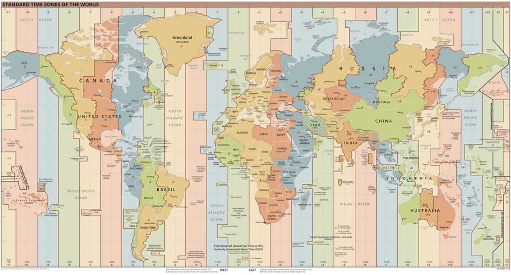

You can also force the creation of a date-time from a date by supplying a timezone:

```r
now()
```

```
[1] "2020-01-29 21:18:50 EST"
```

```r
ymd_hms(now(), tz = "EST")
```

```
[1] "2020-01-29 21:18:50 EST"
```